# Odmowa szczepień

Tomasz Makowski

October 26, 2018

## Znaleziony wykres

Tym razem znalazłem artykuł na portalu money.pl mówiący o braku chęci szczepienia dzieci za darmo, ale z drugiej strony ludzie wydają dużo własnych pieniędzy na szczepienia.  
https://www.money.pl/gospodarka/wiadomosci/artykul/szczepienia-odra-koszty-szczepien,243,0,2418931.html  
Wykres dotyczy powodów odmowy szczepień i jest przedstawiony poniżej.

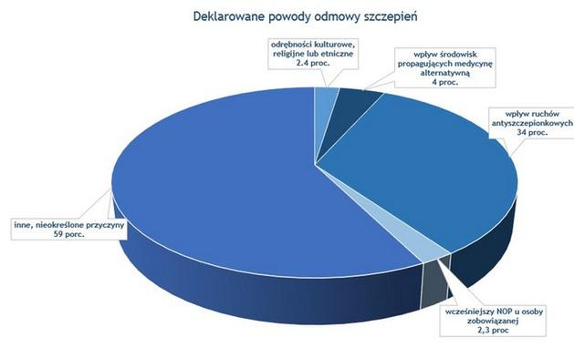

Wykres z artykułu

Na wykresie głównym problemem jest rodzaj wykresu, czyli wykres kołowy 3D. Na takim wykresie ciężko porównywać 2 wartości ze względu na różne kąty w zależności od tego, czy dana informacja jest blisko osi X, czy osi Y. Ciężko porównać wartości 2.3%, 2.4% i 4%. Mimo, że 4% jest wyraźnie większe to nie widać jak bardzo. Poza tym kolory są tylko odcieniami niebieskiego, co w pewnych warunkach może powodować trudności z odczytaniem. Dodatkowo wartości nie sumują się równo do 100%, tylko do 101.7%. Niestety danych surowych nie ma, więc na moim wykresie również wartości nie będą sumować się do 100% (próba przeskalowania skończyła się brakiem różnicy przy 2 najmniejszych wynikach, więc z niej zrezygnowałem).

## Poprawiony wykres

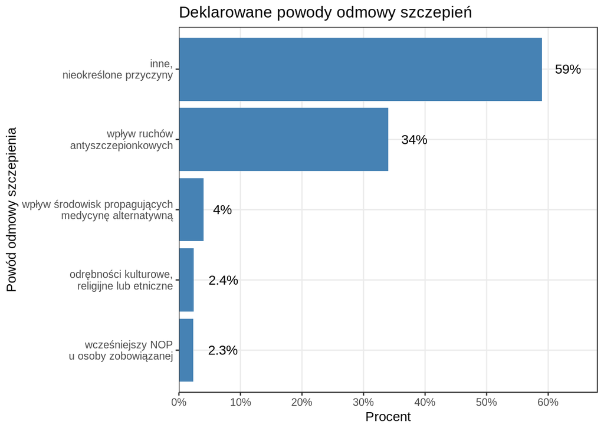

Na poprawionym wykresie łatwiej jest zauważyć różnicę między konkretnymi powodami. Wyniki są również posortowane, dzięki czemu od razu widać, że odrębności kulturowe są niewiele częstszym powodem od wcześniejszego NOP u osoby zobowiązanej.